# mNSC Bulk RNA-Seq Analysis

A Modular and Reproducible Pipeline

Ryan Miller

Last modified: 03 Sep 2025

# Project 250902_mNSC

This R Markdown document serves as the central hub for a modular DESeq2 RNA-seq analysis pipeline. The workflow is designed to be highly reproducible and easily adaptable to new projects by centralizing all configuration parameters.

**Key Features:**

- **Modular Functions:** Core tasks like package loading, gene annotation, quality control, and DESeq2 analysis are handled by external, version-controlled `.R` scripts.
- **Centralized Configuration:** All project-specific paths, parameters, and analysis definitions are set in a single `cfg` list in the chunk below.
- **Dynamic Analysis Plan:** The pipeline programmatically generates analysis plans based on defined subsets and model types, eliminating redundant code.
- **Reproducibility:** The `RUN_ANALYSIS` switch separates time-consuming computation from rapid report generation. Results are cached, and package versions can be managed with `renv`.

# 1. Setup and Configuration

This section loads necessary libraries and functions and defines all project-specific parameters. **This is the only section you need to edit for a new project.**

```r
# =============================================================================
# CHUNK 1: CONFIGURATION SETUP
# =============================================================================

# --- Master Switch ---
# Set to TRUE to run the full, time-consuming analysis.
# Set to FALSE to load the latest saved results and quickly generate the report.
RUN_ANALYSIS <- TRUE

# --- Load Libraries and Child Scripts ---
# These scripts must be in a subfolder named 'scripts'.
source(here::here("scripts", "00_setup.R"))
source(here::here("scripts", "01_genes_mouse.R"))
source(here::here("scripts", "02_QC.R"))
source(here::here("scripts", "03_DESeq2.R"))

# --- Project-Specific Configuration (cfg) ---
cfg <- list(
  # A. General Settings
  date = format(Sys.Date(), "%y%m%d"),
  project_name = "250902_mNSC",

  # B. File Paths (relative to the project root)
  file_samples = here::here("input", "samples.csv"),
  file_gtf = here::here("input", "gencode.vM37.primary_assembly.annotation.gtf.gz"),
  dir_sf = here::here("sf"),
  dir_output = here::here("output"),
  dir_graphs = here::here("graphs"),
  dir_results_csv = here::here("output", "results_csv"),

  # C. Gene Annotation Settings
  filter_gene_types = "protein_coding",
  exclude_patterns = c("RIKEN", "cDNA sequence", "predicted gene"),
  exclude_chromosomes = c("MT", "X", "Y"),

  # D. DESeq2 Settings
  qval_threshold = 0.05,
  lfc_threshold = 1.0,
  filter_min_count = 10,
  # Parameterized filter count

  # E. Experimental Design Definition
  batch_vars = c("SeqBatch"),
  main_vars = c("Host", "Model", "Driver"),
  interaction_vars = c("Model", "Driver"),
  filter_by_factor = "Driver",

  # F. QC Plot Settings
  qc_plot_settings = list(
    project_genes = c("Egfr", "Pdgfra", "Pten", "Cdkn2a"),
    annotation_colors = list(
      Driver = c(
        "EGFRvIII" = "blue",
        "EGFRvV" = "dodgerblue",
        "PDGFRA" = "red"
      ),
      Model = c(
        "NS1" = "#7FC97F",
        "NS2" = "#BEAED4",
        "GBO" = "#FDC086",
        "Tumor" = "#386CB0"
      ),
      Host = c("NSG" = "grey50", "BL6" = "black")
    )
  ),

  # G. Analysis Plan Definition (DYNAMIC)
  # Define the building blocks for the analysis here. The script will
  # programmatically generate all combinations.
  analysis_definitions = list(
    # Define a named list of data subsets to analyze. An empty list means 'all data'.
    subsets = list(
      Full_Dataset = list(),
      NS1_Model = list(Model = "NS1"),
      BL6_Host = list(Host = "BL6")
    ),
    # Define the model types to run on each subset.
    model_types = c("additive", "interaction")
  )
)

# --- Programmatically Generate the Full Analysis Plan ---
# This loop creates the final `cfg$analysis_plan` based on the definitions above.
cfg$analysis_plan <- list()
for (s_name in names(cfg$analysis_definitions$subsets)) {
  for (m_type in cfg$analysis_definitions$model_types) {
    analysis_name <- paste(s_name, m_type, sep = "_")
    cfg$analysis_plan[[analysis_name]] <- list(
      model_type = m_type,
      subset_criteria = cfg$analysis_definitions$subsets[[s_name]]
    )
  }
}
rm(analysis_name, m_type, s_name) # Clean up temp variables
```

# 2. Computational Analysis

This section executes the full analysis when `RUN_ANALYSIS` is `TRUE`. It processes the data according to the `analysis_plan` and saves all results to disk.

# 3. Report Generation

This section loads the saved results (if `RUN_ANALYSIS` is `FALSE`) and generates the final report with tables and figures.

## 3.1 Sample Metadata

The following table displays the metadata for all samples included in the project.

```r
reactable::reactable(
  samples,
  searchable = TRUE,
  filterable = TRUE,
  bordered = TRUE,
  highlight = TRUE,
  defaultPageSize = 10
)
```

|  | fastq_1 | fastq_2 | strandedness | ID | ID2 | Driver | Host | CDKN2AB | PTEN | Model | Clone | Replicate | OriginalOrder | LibQuickID | Random_Sample_No | Adapter | LibraryBatch | SeqBatch | SeqBatchSample |
| --- | --- | --- | --- | --- | --- | --- | --- | --- | --- | --- | --- | --- | --- | --- | --- | --- | --- | --- | --- |
| TK001 | /data/project/MillerLab/projects/mNSC/220902_RB_Tomo/01_fastq/TK_1_S1_R1_001.fastq.gz | NA | auto | TK_1 | TK_001_S1 | EGFRvIII | NSG | Hom_del | Hom_del | NS1 | 15.4.4 | 1 | 1 | TK85 | 85 | 1 | 8 | 8 | S1 |
| TK002 | /data/project/MillerLab/projects/mNSC/220902_RB_Tomo/01_fastq/TK_2_S4_R1_001.fastq.gz | NA | auto | TK_2 | TK_002_S4 | EGFRvIII | NSG | Hom_del | Hom_del | NS1 | 15.4.4 | 2 | 2 | TK100 | 100 | 9 | 9 | 9 | S4 |
| TK003 | /data/project/MillerLab/projects/mNSC/220902_RB_Tomo/01_fastq/TK_3_S11_R1_001.fastq.gz | NA | auto | TK_3 | TK_003_S11 | EGFRvIII | NSG | Hom_del | Hom_del | NS1 | 15.4.4 | 3 | 3 | TK35 | 35 | 25 | 3 | 3 | S11 |
| TK004 | /data/project/MillerLab/projects/mNSC/220902_RB_Tomo/01_fastq/TK_4_S10_R1_001.fastq.gz | NA | auto | TK_4 | TK_004_S10 | EGFRvIII | NSG | Hom_del | Hom_del | NS1 | 15.5.2 | 1 | 4 | TK70 | 70 | 23 | 6 | 6 | S10 |
| TK005 | /data/project/MillerLab/projects/mNSC/220902_RB_Tomo/01_fastq/TK_5_S1_R1_001.fastq.gz | NA | auto | TK_5 | TK_005_S1 | EGFRvIII | NSG | Hom_del | Hom_del | NS1 | 15.5.2 | 2 | 5 | TK25 | 25 | 1 | 3 | 3 | S1 |
| TK006 | /data/project/MillerLab/projects/mNSC/220902_RB_Tomo/01_fastq/TK_6_S6_R1_001.fastq.gz | NA | auto | TK_6 | TK_006_S6 | EGFRvIII | NSG | Hom_del | Hom_del | NS1 | 15.5.2 | 3 | 6 | TK54 | 54 | 11 | 5 | 5 | S6 |
| TK007 | /data/project/MillerLab/projects/mNSC/220902_RB_Tomo/01_fastq/TK_7_S5_R1_001.fastq.gz | NA | auto | TK_7 | TK_007_S5 | EGFRvIII | NSG | Hom_del | Hom_del | NS1 | 15.5.3 | 1 | 7 | TK41 | 41 | 10 | 4 | 4 | S5 |
| TK008 | /data/project/MillerLab/projects/mNSC/220902_RB_Tomo/01_fastq/TK_8_S3_R1_001.fastq.gz | NA | auto | TK_8 | TK_008_S3 | EGFRvIII | NSG | Hom_del | Hom_del | NS1 | 15.5.3 | 2 | 8 | TK99 | 99 | 8 | 9 | 9 | S3 |
| TK009 | /data/project/MillerLab/projects/mNSC/220902_RB_Tomo/01_fastq/TK_9_S4_R1_001.fastq.gz | NA | auto | TK_9 | TK_009_S4 | EGFRvIII | NSG | Hom_del | Hom_del | NS1 | 15.5.3 | 3 | 9 | TK16 | 16 | 9 | 2 | 2 | S4 |
| TK010 | /data/project/MillerLab/projects/mNSC/220902_RB_Tomo/01_fastq/TK_10_S4_R1_001.fastq.gz | NA | auto | TK_10 | TK_010_S4 | EGFRvV | NSG | Hom_del | Hom_del | NS1 | 15.5.5 | 1 | 10 | TK64 | 64 | 9 | 6 | 6 | S4 |

[output cut: 107 more lines]

## 3.2 Quality Control

The plots below provide a QC overview for the `Full_Dataset_additive` analysis. A complete set of QC plots for *every* analysis defined in the `analysis_plan` has been saved to the `graphs/` directory.

### PCA Plot

Principal Component Analysis (PCA) visualizes the sample-to-sample distances. Samples that are biologically similar should cluster together.

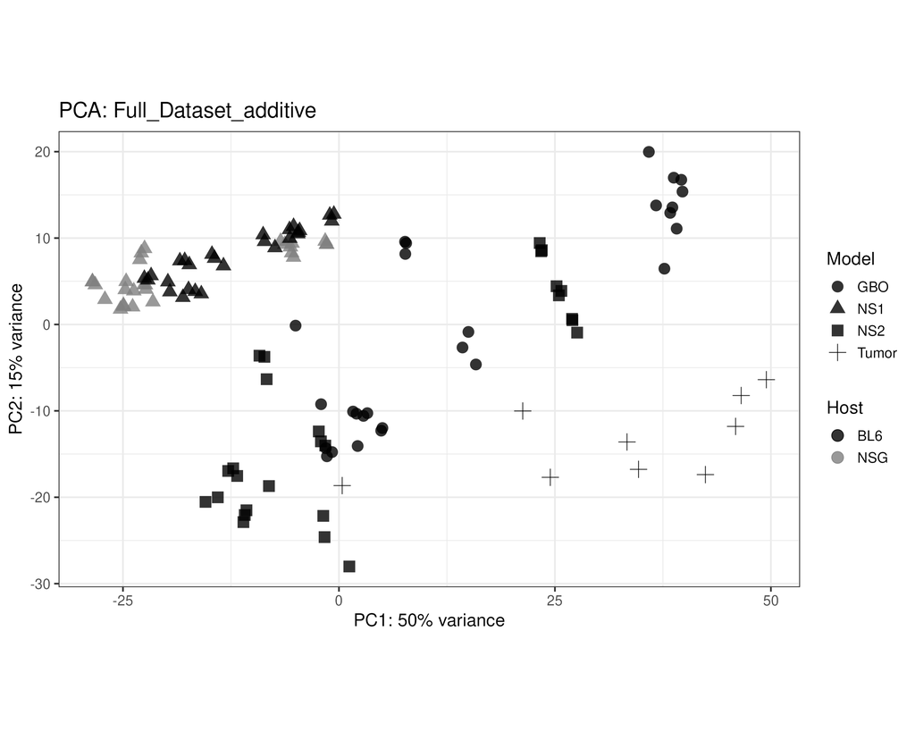

```r
pca_plot_path <- here::here(cfg$dir_graphs,
                            paste0(cfg$date, "_Full_Dataset_additive_PCA.png"))
if (file.exists(pca_plot_path)) {
  knitr::include_graphics(pca_plot_path)
} else {
  "PCA plot not found. Please run the analysis."
}
```

### Sample Distance Heatmap

This heatmap provides another view of sample similarity based on variance-stabilized expression data.

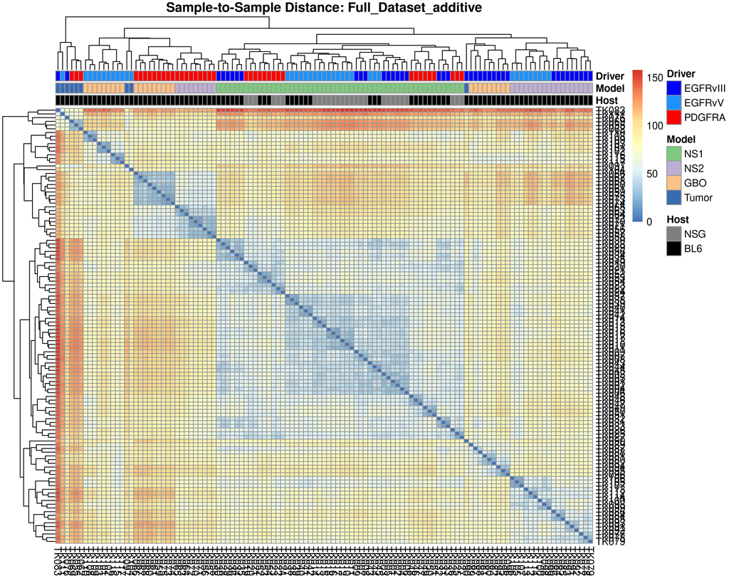

```r
heatmap_plot_path <- here::here(cfg$dir_graphs,
                                paste0(cfg$date, "_Full_Dataset_additive_Heatmap.png"))
if (file.exists(heatmap_plot_path)) {
  knitr::include_graphics(heatmap_plot_path)
} else {
  "Heatmap not found. Please run the analysis."
}
```

## 3.3 Differential Expression Results

- Full, sortable results tables for every comparison are saved as `.csv` files in `output/results_csv/`.
- Volcano plots for every comparison are saved as `.png` files in `graphs/`.

```r
# =============================================================================
# CHUNK 4: DYNAMIC RESULTS REPORTING
# =============================================================================
for (analysis_name in names(all_results_lists)) {
  cat(paste("\n###", gsub("_", " ", analysis_name), "\n"))
  analysis_results <- all_results_lists[[analysis_name]]

  if (is.null(analysis_results) || length(analysis_results) == 0) {
    cat("\nNo valid comparisons were performed for this analysis group.\n")
    next
  }

  for (comp_name in names(analysis_results)) {
    cat(paste("\n####", gsub("_", " ", comp_name), "\n"))
    comp_df <- analysis_results[[comp_name]]

    sig_genes <- comp_df %>%
      dplyr::filter(padj < cfg$qval_threshold)

    if (nrow(sig_genes) > 0) {
      results_table <- sig_genes %>%
        arrange(padj) %>%
        reactable::reactable(
          searchable = TRUE, filterable = TRUE, bordered = TRUE, highlight = TRUE,
          defaultPageSize = 5,
          columns = list(
            log2FoldChange = colDef(format = colFormat(digits = 2)),
            # FIX: Use a custom cell function for scientific notation
            padj = colDef(
              name = "Adjusted P-value",
              cell = function(value) {
                formatC(value, format = "e", digits = 2)
              }
            )
          )
        )
      print(results_table)
    } else {
      cat("\n*No significant genes found for this comparison.*\n")
    }
    cat("\n")
  }
}
```

[output not shown]

### Full Dataset additive

#### Full Dataset additive Host BL6 vs NSG

#### Full Dataset additive Model GBO vs NS1

#### Full Dataset additive Model GBO vs NS2

#### Full Dataset additive Model GBO vs Tumor

#### Full Dataset additive Model NS1 vs NS2

#### Full Dataset additive Model NS1 vs Tumor

#### Full Dataset additive Model NS2 vs Tumor

#### Full Dataset additive Driver EGFRvIII vs EGFRvV

#### Full Dataset additive Driver EGFRvIII vs PDGFRA

#### Full Dataset additive Driver EGFRvV vs PDGFRA

### Full Dataset interaction

#### Full Dataset interaction Host BL6 vs NSG

#### Full Dataset interaction Model GBO vs NS1

#### Full Dataset interaction Model GBO vs NS2

#### Full Dataset interaction Model GBO vs Tumor

#### Full Dataset interaction Model NS1 vs NS2

#### Full Dataset interaction Model NS1 vs Tumor

#### Full Dataset interaction Model NS2 vs Tumor

#### Full Dataset interaction Driver EGFRvIII vs EGFRvV

#### Full Dataset interaction Driver EGFRvIII vs PDGFRA

#### Full Dataset interaction Driver EGFRvV vs PDGFRA

### NS1 Model additive

#### NS1 Model additive Host BL6 vs NSG

#### NS1 Model additive Driver EGFRvIII vs EGFRvV

#### NS1 Model additive Driver EGFRvIII vs PDGFRA

#### NS1 Model additive Driver EGFRvV vs PDGFRA

### NS1 Model interaction

#### NS1 Model interaction Host BL6 vs NSG

#### NS1 Model interaction Driver EGFRvIII vs EGFRvV

#### NS1 Model interaction Driver EGFRvIII vs PDGFRA

#### NS1 Model interaction Driver EGFRvV vs PDGFRA

### BL6 Host additive

#### BL6 Host additive Model GBO vs NS1

#### BL6 Host additive Model GBO vs NS2

#### BL6 Host additive Model GBO vs Tumor

#### BL6 Host additive Model NS1 vs NS2

#### BL6 Host additive Model NS1 vs Tumor

#### BL6 Host additive Model NS2 vs Tumor

#### BL6 Host additive Driver EGFRvIII vs EGFRvV

#### BL6 Host additive Driver EGFRvIII vs PDGFRA

#### BL6 Host additive Driver EGFRvV vs PDGFRA

### BL6 Host interaction

#### BL6 Host interaction Model GBO vs NS1

#### BL6 Host interaction Model GBO vs NS2

#### BL6 Host interaction Model GBO vs Tumor

#### BL6 Host interaction Model NS1 vs NS2

#### BL6 Host interaction Model NS1 vs Tumor

#### BL6 Host interaction Model NS2 vs Tumor

#### BL6 Host interaction Driver EGFRvIII vs EGFRvV

#### BL6 Host interaction Driver EGFRvIII vs PDGFRA

#### BL6 Host interaction Driver EGFRvV vs PDGFRA

# 4. Session